# Aedes aegypti Brazil - Ancetry analysis with Admixture.

## 5. Structure plots

### 5.1 Brazil set

Download the data

```bash
rsync -chavzP --stats \
--include='*/' \
--include='*.Q' \
--include='*.txt' \
--exclude='*' \
lvc26@mccleary.ycrc.yale.edu:/gpfs/ycga/project/caccone/lvc26/admixture/aegypti/brazil/* \
/Users/lucianocosme/Library/CloudStorage/Dropbox/popgen/brazil/aegypti/output/populations/admixture/brazil
```

Check the downloaded data

```bash
ls -1 output/populations/admixture/brazil/run1/*Q* | tail
```

#### 5.1.1 Create plot with Q matrix k=8 to compare with fastStructure

Make plot

```r
# Extract ancestry coefficients
k8run1 <- read_delim(
  here("output", "populations", "admixture", "brazil", "run1", "brazil_2018.8.Q"),
  delim = " ", # Specify the delimiter if different from the default (comma)
  col_names = FALSE,
  show_col_types = FALSE
)

head(k8run1)
```

```
## # A tibble: 6 × 8
##        X1      X2      X3    X4     X5      X6      X7      X8
##     <dbl>   <dbl>   <dbl> <dbl>  <dbl>   <dbl>   <dbl>   <dbl>
## 1 0.00722 0.00001 0.0831  0.674 0.235  0.00001 0.00001 0.00001
## 2 0.00001 0.0241  0.0639  0.809 0.103  0.00001 0.00001 0.00001
## 3 0.496   0.00001 0.00001 0.434 0.0704 0.00001 0.00001 0.00001
## 4 0.00001 0.00001 0.00001 0.706 0.285  0.00001 0.00844 0.00001
## 5 0.00001 0.00001 0.110   0.716 0.147  0.00001 0.0268  0.00001
## 6 0.00001 0.00001 0.00001 0.843 0.0726 0.0190  0.0253  0.0397
```

The fam file

```r
fam_file <- here(
  "output", "populations", "snps_sets", "brazil_2018.fam"
)

# Read the .fam file
fam_data <- read.table(fam_file,
                       header = FALSE,
                       col.names = c("FamilyID", "IndividualID", "PaternalID", "MaternalID", "Sex", "Phenotype"))

# View the first few rows
head(fam_data)
```

```
##   FamilyID IndividualID PaternalID MaternalID Sex Phenotype
## 1      PAR          236          0          0   0        -9
## 2      PAR          237          0          0   0        -9
## 3      PAR          238          0          0   0        -9
## 4      PAR          239          0          0   0        -9
## 5      PAR          240          0          0   0        -9
## 6      PAR          241          0          0   0        -9
```

Create ID column

```r
# Change column name
colnames(fam_data)[colnames(fam_data) == "IndividualID"] <- "ind"

# Change column name
colnames(fam_data)[colnames(fam_data) == "FamilyID"] <- "pop"

# Select ID
fam_data <- fam_data |>
  dplyr::select("ind", "pop")

# View the first few rows
head(fam_data)
```

```
##   ind pop
## 1 236 PAR
## 2 237 PAR
## 3 238 PAR
## 4 239 PAR
## 5 240 PAR
## 6 241 PAR
```

Add it to matrix

```r
k8run1 <- fam_data |>
  dplyr::select(ind, pop) |>
  bind_cols(k8run1)

head(k8run1)
```

```
##   ind pop       X1       X2       X3       X4       X5      X6       X7
## 1 236 PAR 0.007223 0.000010 0.083138 0.674159 0.235439 0.00001 0.000010
## 2 237 PAR 0.000010 0.024118 0.063861 0.808547 0.103434 0.00001 0.000010
## 3 238 PAR 0.495842 0.000010 0.000010 0.433680 0.070427 0.00001 0.000010
## 4 239 PAR 0.000010 0.000010 0.000010 0.706436 0.285075 0.00001 0.008439
## 5 240 PAR 0.000010 0.000010 0.110059 0.716393 0.146702 0.00001 0.026806
## 6 241 PAR 0.000010 0.000010 0.000010 0.843450 0.072587 0.01895 0.025324
##         X8
## 1 0.000010
## 2 0.000010
## 3 0.000010
## 4 0.000010
## 5 0.000010
## 6 0.039658
```

Rename the columns

```r
# Rename the columns starting from the third one
k8run1 <- k8run1 |>
  rename_with(~paste0("v", seq_along(.x)), .cols = -c(ind, pop))

# View the first few rows
head(k8run1)
```

```
##   ind pop       v1       v2       v3       v4       v5      v6       v7
## 1 236 PAR 0.007223 0.000010 0.083138 0.674159 0.235439 0.00001 0.000010
## 2 237 PAR 0.000010 0.024118 0.063861 0.808547 0.103434 0.00001 0.000010
## 3 238 PAR 0.495842 0.000010 0.000010 0.433680 0.070427 0.00001 0.000010
## 4 239 PAR 0.000010 0.000010 0.000010 0.706436 0.285075 0.00001 0.008439
## 5 240 PAR 0.000010 0.000010 0.110059 0.716393 0.146702 0.00001 0.026806
## 6 241 PAR 0.000010 0.000010 0.000010 0.843450 0.072587 0.01895 0.025324
##         v8
## 1 0.000010
## 2 0.000010
## 3 0.000010
## 4 0.000010
## 5 0.000010
## 6 0.039658
```

Import sample locations

```r
cities <- readRDS(here("output", "populations", "cities.rds"))
head(cities)
```

```
## # A tibble: 6 × 7
##   pop   city         state latitude longitude region       biome
##   <chr> <chr>        <chr>    <dbl>     <dbl> <chr>        <chr>
## 1 BRA   Brasilia     DF      -15.8      -47.9 Central-West Cerrado
## 2 GOI   Goiania      GO      -16.7      -49.3 Central-West Cerrado
## 3 CAM   Campo Grande MS      -20.4      -54.6 Central-West Pantanal
## 4 CUI   Cuiaba       MT      -15.6      -56.1 Central-West Cerrado
## 5 RBR   Rio Branco   AC       -9.97     -67.8 North        Amazon
## 6 MAN   Manaus       AM       -3.13     -60.0 North        Amazon
```

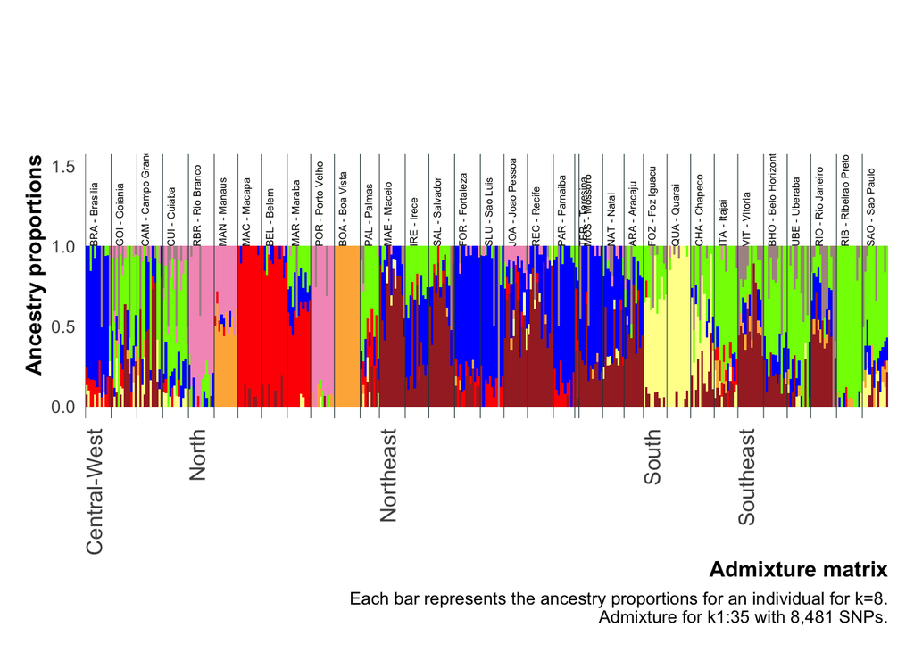

```r
source(
  here(
    "scripts", "analysis", "my_theme3.R"
  )
)

# Melt the data frame for plotting
Q_melted <- k8run1 |>
  pivot_longer(
    cols = -c(ind, pop),
    names_to = "variable",
    values_to = "value"
  )
# Join with sampling_loc to get sampling localities
Q_joined <- Q_melted |>
  left_join(cities, by = c("pop" = "pop"))

# # Create a combined variable for Region and Country
# Q_joined <- Q_joined |>
#   mutate(Region_Country = interaction(Region, Country, sep = "_"))

# Order the combined variable by Region and Country, then by individual
Q_ordered <- Q_joined |>
  arrange(region, state, city, ind) |>
  mutate(ind = factor(ind, levels = unique(ind)))  # Convert ind to a factor with levels in the desired order

# Add labels: country names for the first individual in each country, NA for all other individuals
Q_ordered <- Q_ordered |>
  group_by(region) |>
  mutate(label = ifelse(row_number() == 1, as.character(region), NA))

# Group by individual and variable, calculate mean ancestry proportions
Q_grouped <- Q_ordered |>
  group_by(ind, variable) |>
  summarise(value = mean(value), .groups = "drop")

# Create a data frame for borders
borders <-
  data.frame(region = unique(Q_ordered$region))

# Add the order of the last individual of each country to ensure correct placement of borders
borders$order <-
  sapply(borders$region, function(rc)
    max(which(Q_ordered$region == rc))) + 0.5  # Shift borders to the right edge of the bars

# Select only the first occurrence of each country in the ordered data
label_df <- Q_ordered |>
  filter(!is.na(label)) |>
  distinct(label, .keep_all = TRUE)

# Create a custom label function
label_func <- function(x) {
  labels <- rep("", length(x))
  labels[x %in% label_df$ind] <- label_df$label
  labels
}

# Calculate the position of lines
border_positions <- Q_ordered |>
  group_by(region) |>
  summarise(pos = max(as.numeric(ind)) + 0)

# Calculate the position of population labels and bars
pop_labels <- Q_ordered |>
  mutate(Name = paste(pop, city, sep = " - ")) |>
  group_by(pop) |>
  slice_head(n = 1) |>
  ungroup() |>
  dplyr::select(ind, city, biome, region, Name) |>
  mutate(pos = as.numeric(ind))  # calculate position of population labels

pop_labels_bars <- pop_labels |>
  mutate(pos = as.numeric(ind)  - .5)


# Calculate the position of lines
border_positions <- Q_ordered |>
  group_by(region) |>
  summarise(pos = max(as.numeric(ind)) - 1)


pop_labels_bars <- pop_labels |>
  mutate(pos = as.numeric(ind)  - .5)

# Function to filter and normalize data
normalize_data <- function(df, min_value) {
  df |>
    filter(value > min_value) |>
    group_by(ind) |>
    mutate(value = value / sum(value))
}

# Use the function
Q_grouped_filtered <- normalize_data(Q_grouped, 0.05)
#

color_palette <- c(
  "v1" = "#AE9393",
  "v2" = "#F49AC2",
  "v3" = "#7FFF00",
  "v4" = "blue",
  "v5" = "red",
  "v6" = "#FFB347",
  "v7" = "#FFFF99",
  "v8" = "brown"
)

# Generate all potential variable names
all_variables <- paste0("v", 1:8)

# Map each variable to a name
color_mapping <- data.frame(variable = all_variables,
                            color = names(color_palette))

# Merge with Q_grouped_filtered
Q_grouped_filtered <- merge(Q_grouped_filtered, color_mapping, by = "variable")

# Create the plot
ggplot(Q_grouped_filtered, aes(x = as.factor(ind), y = value, fill = color)) +
  geom_bar(stat = 'identity', width = 1) +
  geom_vline(
    data = pop_labels_bars,
    aes(xintercept = pos),
    color = "#2C444A",
    linewidth = .2
  ) +
  geom_text(
    data = pop_labels,
    aes(x = as.numeric(ind), y = 1, label = Name),
    vjust = 1.5,
    hjust = 0,
    size = 2,
    angle = 90,
    inherit.aes = FALSE
  ) +
  my_theme() +
  theme(
    axis.text.x = element_text(
      angle = 90,
      hjust = 1,
      size = 12
    ),
    legend.position = "none",
    plot.margin = unit(c(3, 0.5, 0.5, 0.5), "cm")
  ) +
  xlab("Admixture matrix") +
  ylab("Ancestry proportions") +
  labs(caption = "Each bar represents the ancestry proportions for an individual for k=8.\n Admixture for k1:35 with 8,481 SNPs.") +
  scale_x_discrete(labels = label_func) +
  scale_fill_manual(values = color_palette) +
  expand_limits(y = c(0, 1.5))
```

```r
# save it
ggsave(
  here("output", "populations", "figures", "admixture_brazil_k8.pdf"),
  width  = 12,
  height = 6,
  units  = "in",
  device = cairo_pdf
)
```

We see more admixture across the sampling localities than we saw with fastStructure simple prior. We still see five major clusters separated by geographical regions.

#### 5.1.1 Create plot with Q matrix k=11

Make plot

```r
# Extract ancestry coefficients
k11run1 <- read_delim(
  here("output", "populations", "admixture", "brazil", "run1", "brazil_2018.11.Q"),
  delim = " ", # Specify the delimiter if different from the default (comma)
  col_names = FALSE,
  show_col_types = FALSE
)

head(k11run1)
```

```
## # A tibble: 6 × 11
##        X1     X2      X3    X4      X5      X6      X7      X8     X9     X10
##     <dbl>  <dbl>   <dbl> <dbl>   <dbl>   <dbl>   <dbl>   <dbl>  <dbl>   <dbl>
## 1 0.00327 0.184  0.00001 0.333 0.0383  0.0927  0.00001 0.00001 0.349  0.00001
## 2 0.00001 0.0337 0.0674  0.713 0.00001 0.112   0.00001 0.0282  0.0459 0.00001
## 3 0.479   0.0298 0.00001 0.374 0.00001 0.00001 0.00001 0.00001 0.117  0.00001
## 4 0.00001 0.228  0.00001 0.561 0.00001 0.00001 0.00001 0.00001 0.209  0.00001
## 5 0.00001 0.103  0.00001 0.471 0.0314  0.0810  0.00001 0.0149  0.288  0.00001
## 6 0.00001 0.0343 0.00001 0.589 0.0456  0.00001 0.0115  0.00001 0.317  0.00001
## # ℹ 1 more variable: X11 <dbl>
```

The fam file

```r
fam_file <- here(
  "output", "populations", "snps_sets", "brazil_2018.fam"
)

# Read the .fam file
fam_data <- read.table(fam_file,
                       header = FALSE,
                       col.names = c("FamilyID", "IndividualID", "PaternalID", "MaternalID", "Sex", "Phenotype"))

# View the first few rows
head(fam_data)
```

```
##   FamilyID IndividualID PaternalID MaternalID Sex Phenotype
## 1      PAR          236          0          0   0        -9
## 2      PAR          237          0          0   0        -9
## 3      PAR          238          0          0   0        -9
## 4      PAR          239          0          0   0        -9
## 5      PAR          240          0          0   0        -9
## 6      PAR          241          0          0   0        -9
```

Create ID column

```r
# Change column name
colnames(fam_data)[colnames(fam_data) == "IndividualID"] <- "ind"

# Change column name
colnames(fam_data)[colnames(fam_data) == "FamilyID"] <- "pop"

# Select ID
fam_data <- fam_data |>
  dplyr::select("ind", "pop")

# View the first few rows
head(fam_data)
```

```
##   ind pop
## 1 236 PAR
## 2 237 PAR
## 3 238 PAR
## 4 239 PAR
## 5 240 PAR
## 6 241 PAR
```

Add it to matrix

```r
k11run1 <- fam_data |>
  dplyr::select(ind, pop) |>
  bind_cols(k11run1)

head(k11run1)
```

```
##   ind pop       X1       X2       X3       X4       X5       X6       X7
## 1 236 PAR 0.003272 0.184183 0.000010 0.332964 0.038333 0.092689 0.000010
## 2 237 PAR 0.000010 0.033659 0.067406 0.713267 0.000010 0.111505 0.000010
## 3 238 PAR 0.479046 0.029830 0.000010 0.373780 0.000010 0.000010 0.000010
## 4 239 PAR 0.000010 0.228062 0.000010 0.561204 0.000010 0.000010 0.000010
## 5 240 PAR 0.000010 0.102956 0.000010 0.471448 0.031363 0.081042 0.000010
## 6 241 PAR 0.000010 0.034270 0.000010 0.588945 0.045630 0.000010 0.011537
##         X8       X9   X10      X11
## 1 0.000010 0.348510 1e-05 0.000010
## 2 0.028243 0.045869 1e-05 0.000010
## 3 0.000010 0.117274 1e-05 0.000010
## 4 0.000010 0.208574 1e-05 0.002091
## 5 0.014881 0.287650 1e-05 0.010620
## 6 0.000010 0.317290 1e-05 0.002279
```

Rename the columns

```r
# Rename the columns starting from the third one
k11run1 <- k11run1 |>
  rename_with(~paste0("v", seq_along(.x)), .cols = -c(ind, pop))

# View the first few rows
head(k11run1)
```

```
##   ind pop       v1       v2       v3       v4       v5       v6       v7
## 1 236 PAR 0.003272 0.184183 0.000010 0.332964 0.038333 0.092689 0.000010
## 2 237 PAR 0.000010 0.033659 0.067406 0.713267 0.000010 0.111505 0.000010
## 3 238 PAR 0.479046 0.029830 0.000010 0.373780 0.000010 0.000010 0.000010
## 4 239 PAR 0.000010 0.228062 0.000010 0.561204 0.000010 0.000010 0.000010
## 5 240 PAR 0.000010 0.102956 0.000010 0.471448 0.031363 0.081042 0.000010
## 6 241 PAR 0.000010 0.034270 0.000010 0.588945 0.045630 0.000010 0.011537
##         v8       v9   v10      v11
## 1 0.000010 0.348510 1e-05 0.000010
## 2 0.028243 0.045869 1e-05 0.000010
## 3 0.000010 0.117274 1e-05 0.000010
## 4 0.000010 0.208574 1e-05 0.002091
## 5 0.014881 0.287650 1e-05 0.010620
## 6 0.000010 0.317290 1e-05 0.002279
```

Import sample locations

```r
cities <- readRDS(here("output", "populations", "cities.rds"))
head(cities)
```

```
## # A tibble: 6 × 7
##   pop   city         state latitude longitude region       biome
##   <chr> <chr>        <chr>    <dbl>     <dbl> <chr>        <chr>
## 1 BRA   Brasilia     DF      -15.8      -47.9 Central-West Cerrado
## 2 GOI   Goiania      GO      -16.7      -49.3 Central-West Cerrado
## 3 CAM   Campo Grande MS      -20.4      -54.6 Central-West Pantanal
## 4 CUI   Cuiaba       MT      -15.6      -56.1 Central-West Cerrado
## 5 RBR   Rio Branco   AC       -9.97     -67.8 North        Amazon
## 6 MAN   Manaus       AM       -3.13     -60.0 North        Amazon
```

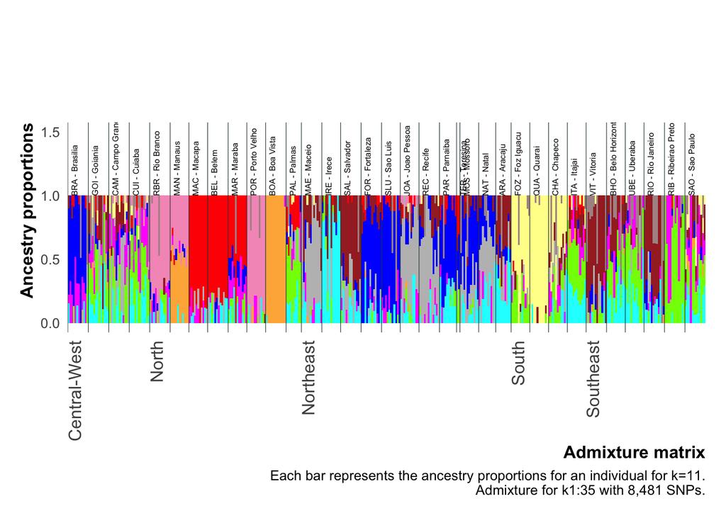

```r
source(
  here(
    "scripts", "analysis", "my_theme3.R"
  )
)

# Melt the data frame for plotting
Q_melted <- k11run1 |>
  pivot_longer(
    cols = -c(ind, pop),
    names_to = "variable",
    values_to = "value"
  )
# Join with sampling_loc to get sampling localities
Q_joined <- Q_melted |>
  left_join(cities, by = c("pop" = "pop"))

# # Create a combined variable for Region and Country
# Q_joined <- Q_joined |>
#   mutate(Region_Country = interaction(Region, Country, sep = "_"))

# Order the combined variable by Region and Country, then by individual
Q_ordered <- Q_joined |>
  arrange(region, state, city, ind) |>
  mutate(ind = factor(ind, levels = unique(ind)))  # Convert ind to a factor with levels in the desired order

# Add labels: country names for the first individual in each country, NA for all other individuals
Q_ordered <- Q_ordered |>
  group_by(region) |>
  mutate(label = ifelse(row_number() == 1, as.character(region), NA))

# Group by individual and variable, calculate mean ancestry proportions
Q_grouped <- Q_ordered |>
  group_by(ind, variable) |>
  summarise(value = mean(value), .groups = "drop")

# Create a data frame for borders
borders <-
  data.frame(region = unique(Q_ordered$region))

# Add the order of the last individual of each country to ensure correct placement of borders
borders$order <-
  sapply(borders$region, function(rc)
    max(which(Q_ordered$region == rc))) + 0.5  # Shift borders to the right edge of the bars

# Select only the first occurrence of each country in the ordered data
label_df <- Q_ordered |>
  filter(!is.na(label)) |>
  distinct(label, .keep_all = TRUE)

# Create a custom label function
label_func <- function(x) {
  labels <- rep("", length(x))
  labels[x %in% label_df$ind] <- label_df$label
  labels
}

# Calculate the position of lines
border_positions <- Q_ordered |>
  group_by(region) |>
  summarise(pos = max(as.numeric(ind)) + 0)

# Calculate the position of population labels and bars
pop_labels <- Q_ordered |>
  mutate(Name = paste(pop, city, sep = " - ")) |>
  group_by(pop) |>
  slice_head(n = 1) |>
  ungroup() |>
  dplyr::select(ind, city, biome, region, Name) |>
  mutate(pos = as.numeric(ind))  # calculate position of population labels

pop_labels_bars <- pop_labels |>
  mutate(pos = as.numeric(ind)  - .5)


# Calculate the position of lines
border_positions <- Q_ordered |>
  group_by(region) |>
  summarise(pos = max(as.numeric(ind)) - 1)


pop_labels_bars <- pop_labels |>
  mutate(pos = as.numeric(ind)  - .5)

# Function to filter and normalize data
normalize_data <- function(df, min_value) {
  df |>
    filter(value > min_value) |>
    group_by(ind) |>
    mutate(value = value / sum(value))
}

# Use the function
Q_grouped_filtered <- normalize_data(Q_grouped, 0.05)
#

color_palette <- c(
  "v1" = "#AE9393",
  "v2" = "red",
  "v3" = "brown",
  "v4" = "blue",
  "v5" = "gray",
  "v6" = "magenta",
  "v7" = "#FFB347",
  "v8" = "#7FFF00",
  "v9" = "cyan",
  "v10" = "#F49AC2",
  "v11" = "#FFFF99"
)

# Generate all potential variable names
all_variables <- paste0("v", 1:11)

# Map each variable to a name
color_mapping <- data.frame(variable = all_variables,
                            color = names(color_palette))

# Merge with Q_grouped_filtered
Q_grouped_filtered <- merge(Q_grouped_filtered, color_mapping, by = "variable")

# Create the plot
ggplot(Q_grouped_filtered, aes(x = as.factor(ind), y = value, fill = color)) +
  geom_bar(stat = 'identity', width = 1) +
  geom_vline(
    data = pop_labels_bars,
    aes(xintercept = pos),
    color = "#2C444A",
    linewidth = .2
  ) +
  geom_text(
    data = pop_labels,
    aes(x = as.numeric(ind), y = 1, label = Name),
    vjust = 1.5,
    hjust = 0,
    size = 2,
    angle = 90,
    inherit.aes = FALSE
  ) +
  my_theme() +
  theme(
    axis.text.x = element_text(
      angle = 90,
      hjust = 1,
      size = 12
    ),
    legend.position = "none",
    plot.margin = unit(c(3, 0.5, 0.5, 0.5), "cm")
  ) +
  xlab("Admixture matrix") +
  ylab("Ancestry proportions") +
  labs(caption = "Each bar represents the ancestry proportions for an individual for k=11.\n Admixture for k1:35 with 8,481 SNPs.") +
  scale_x_discrete(labels = label_func) +
  scale_fill_manual(values = color_palette) +
  expand_limits(y = c(0, 1.5))
```

```r
# save it
ggsave(
  here("output", "populations", "figures", "admixture_brazil_k11.pdf"),
  width  = 12,
  height = 6,
  units  = "in",
  device = cairo_pdf
)
```

#### 5.1.1 Create plot with Q matrix k=5

Make plot

```r
# Extract ancestry coefficients
k5run1 <- read_delim(
  here("output", "populations", "admixture", "brazil", "run1", "brazil_2018.5.Q"),
  delim = " ", # Specify the delimiter if different from the default (comma)
  col_names = FALSE,
  show_col_types = FALSE
)

head(k5run1)
```

```
## # A tibble: 6 × 5
##      X1      X2      X3    X4      X5
##   <dbl>   <dbl>   <dbl> <dbl>   <dbl>
## 1 0.434 0.111   0.00001 0.454 0.00001
## 2 0.335 0.100   0.00001 0.565 0.00001
## 3 0.222 0.0872  0.162   0.528 0.00001
## 4 0.565 0.00001 0.00001 0.435 0.00001
## 5 0.379 0.137   0.00001 0.484 0.00001
## 6 0.321 0.0352  0.00001 0.644 0.00001
```

The fam file

```r
fam_file <- here(
  "output", "populations", "snps_sets", "brazil_2018.fam"
)

# Read the .fam file
fam_data <- read.table(fam_file,
                       header = FALSE,
                       col.names = c("FamilyID", "IndividualID", "PaternalID", "MaternalID", "Sex", "Phenotype"))

# View the first few rows
head(fam_data)
```

```
##   FamilyID IndividualID PaternalID MaternalID Sex Phenotype
## 1      PAR          236          0          0   0        -9
## 2      PAR          237          0          0   0        -9
## 3      PAR          238          0          0   0        -9
## 4      PAR          239          0          0   0        -9
## 5      PAR          240          0          0   0        -9
## 6      PAR          241          0          0   0        -9
```

Create ID column

```r
# Change column name
colnames(fam_data)[colnames(fam_data) == "IndividualID"] <- "ind"


# Change column name
colnames(fam_data)[colnames(fam_data) == "FamilyID"] <- "pop"

# Select ID
fam_data <- fam_data |>
  dplyr::select("ind", "pop")

# View the first few rows
head(fam_data)
```

```
##   ind pop
## 1 236 PAR
## 2 237 PAR
## 3 238 PAR
## 4 239 PAR
## 5 240 PAR
## 6 241 PAR
```

Add it to matrix

```r
k5run1 <- fam_data |>
  dplyr::select(ind, pop) |>
  bind_cols(k5run1)

head(k5run1)
```

```
##   ind pop       X1       X2       X3       X4    X5
## 1 236 PAR 0.434463 0.111440 0.000010 0.454078 1e-05
## 2 237 PAR 0.334726 0.100439 0.000010 0.564815 1e-05
## 3 238 PAR 0.222214 0.087241 0.162335 0.528201 1e-05
## 4 239 PAR 0.565338 0.000010 0.000010 0.434632 1e-05
## 5 240 PAR 0.379016 0.136629 0.000010 0.484335 1e-05
## 6 241 PAR 0.320567 0.035153 0.000010 0.644260 1e-05
```

Rename the columns

```r
# Rename the columns starting from the third one
k5run1 <- k5run1 |>
  rename_with(~paste0("v", seq_along(.x)), .cols = -c(ind, pop))

# View the first few rows
head(k5run1)
```

```
##   ind pop       v1       v2       v3       v4    v5
## 1 236 PAR 0.434463 0.111440 0.000010 0.454078 1e-05
## 2 237 PAR 0.334726 0.100439 0.000010 0.564815 1e-05
## 3 238 PAR 0.222214 0.087241 0.162335 0.528201 1e-05
## 4 239 PAR 0.565338 0.000010 0.000010 0.434632 1e-05
## 5 240 PAR 0.379016 0.136629 0.000010 0.484335 1e-05
## 6 241 PAR 0.320567 0.035153 0.000010 0.644260 1e-05
```

Import sample locations

```r
sampling_loc <- readRDS(here("output", "populations", "cities.rds"))
head(sampling_loc)
```

```
## # A tibble: 6 × 7
##   pop   city         state latitude longitude region       biome
##   <chr> <chr>        <chr>    <dbl>     <dbl> <chr>        <chr>
## 1 BRA   Brasilia     DF      -15.8      -47.9 Central-West Cerrado
## 2 GOI   Goiania      GO      -16.7      -49.3 Central-West Cerrado
## 3 CAM   Campo Grande MS      -20.4      -54.6 Central-West Pantanal
## 4 CUI   Cuiaba       MT      -15.6      -56.1 Central-West Cerrado
## 5 RBR   Rio Branco   AC       -9.97     -67.8 North        Amazon
## 6 MAN   Manaus       AM       -3.13     -60.0 North        Amazon
```

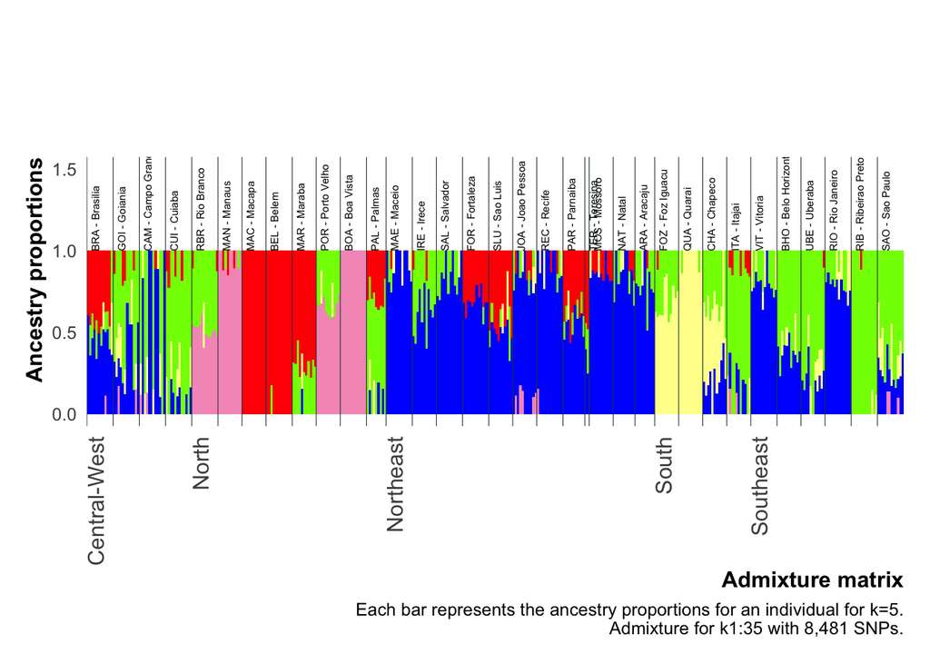

```r
source(
  here(
    "scripts", "analysis", "my_theme3.R"
  )
)

# Melt the data frame for plotting
Q_melted <- k5run1 |>
  pivot_longer(
    cols = -c(ind, pop),
    names_to = "variable",
    values_to = "value"
  )
# Join with sampling_loc to get sampling localities
Q_joined <- Q_melted |>
  left_join(cities, by = c("pop" = "pop"))

# # Create a combined variable for Region and Country
# Q_joined <- Q_joined |>
#   mutate(Region_Country = interaction(Region, Country, sep = "_"))

# Order the combined variable by Region and Country, then by individual
Q_ordered <- Q_joined |>
  arrange(region, state, city, ind) |>
  mutate(ind = factor(ind, levels = unique(ind)))  # Convert ind to a factor with levels in the desired order

# Add labels: country names for the first individual in each country, NA for all other individuals
Q_ordered <- Q_ordered |>
  group_by(region) |>
  mutate(label = ifelse(row_number() == 1, as.character(region), NA))

# Group by individual and variable, calculate mean ancestry proportions
Q_grouped <- Q_ordered |>
  group_by(ind, variable) |>
  summarise(value = mean(value), .groups = "drop")

# Create a data frame for borders
borders <-
  data.frame(region = unique(Q_ordered$region))

# Add the order of the last individual of each country to ensure correct placement of borders
borders$order <-
  sapply(borders$region, function(rc)
    max(which(Q_ordered$region == rc))) + 0.5  # Shift borders to the right edge of the bars

# Select only the first occurrence of each country in the ordered data
label_df <- Q_ordered |>
  filter(!is.na(label)) |>
  distinct(label, .keep_all = TRUE)

# Create a custom label function
label_func <- function(x) {
  labels <- rep("", length(x))
  labels[x %in% label_df$ind] <- label_df$label
  labels
}

# Calculate the position of lines
border_positions <- Q_ordered |>
  group_by(region) |>
  summarise(pos = max(as.numeric(ind)) + 0)

# Calculate the position of population labels and bars
pop_labels <- Q_ordered |>
  mutate(Name = paste(pop, city, sep = " - ")) |>
  group_by(pop) |>
  slice_head(n = 1) |>
  ungroup() |>
  dplyr::select(ind, city, biome, region, Name) |>
  mutate(pos = as.numeric(ind))  # calculate position of population labels

pop_labels_bars <- pop_labels |>
  mutate(pos = as.numeric(ind)  - .5)


# Calculate the position of lines
border_positions <- Q_ordered |>
  group_by(region) |>
  summarise(pos = max(as.numeric(ind)) - 1)


pop_labels_bars <- pop_labels |>
  mutate(pos = as.numeric(ind)  - .5)

# Function to filter and normalize data
normalize_data <- function(df, min_value) {
  df |>
    filter(value > min_value) |>
    group_by(ind) |>
    mutate(value = value / sum(value))
}

# Use the function
Q_grouped_filtered <- normalize_data(Q_grouped, 0.1)
#

color_palette <- c(
  "v1" = "red",
  "v2" = "#7FFF00",
  "v3" = "#FFFF99",
  "v4" = "blue",
  "v5" = "#F49AC2"#,
  # "v6" = "#AE9393",
  # "v7" = "#FFB347",
  # "v8" = "brown"
)

# Generate all potential variable names
all_variables <- paste0("v", 1:5)

# Map each variable to a name
color_mapping <- data.frame(variable = all_variables,
                            color = names(color_palette))

# Merge with Q_grouped_filtered
Q_grouped_filtered <- merge(Q_grouped_filtered, color_mapping, by = "variable")

# Create the plot
ggplot(Q_grouped_filtered, aes(x = as.factor(ind), y = value, fill = color)) +
  geom_bar(stat = 'identity', width = 1) +
  geom_vline(
    data = pop_labels_bars,
    aes(xintercept = pos),
    color = "#2C444A",
    linewidth = .2
  ) +
  geom_text(
    data = pop_labels,
    aes(x = as.numeric(ind), y = 1, label = Name),
    vjust = 1.5,
    hjust = 0,
    size = 2,
    angle = 90,
    inherit.aes = FALSE
  ) +
  my_theme() +
  theme(
    axis.text.x = element_text(
      angle = 90,
      hjust = 1,
      size = 12
    ),
    legend.position = "none",
    plot.margin = unit(c(3, 0.5, 0.5, 0.5), "cm")
  ) +
  xlab("Admixture matrix") +
  ylab("Ancestry proportions") +
  labs(caption = "Each bar represents the ancestry proportions for an individual for k=5.\n Admixture for k1:35 with 8,481 SNPs.") +
  scale_x_discrete(labels = label_func) +
  scale_fill_manual(values = color_palette) +
  expand_limits(y = c(0, 1.5))
```

```r
# save it
ggsave(
  here("output", "populations", "figures", "admixture_brazil_k5.pdf"),
  width  = 12,
  height = 6,
  units  = "in",
  device = cairo_pdf
)
```

We see more admixture across the sampling localities than we saw with fastStructure simple prior. We still see five major clusters separated by geographical regions.